# Juvenile snowshoe hares in Bonanza Creek: exploratory report

## Section 2: Visualize juvenile hare weights

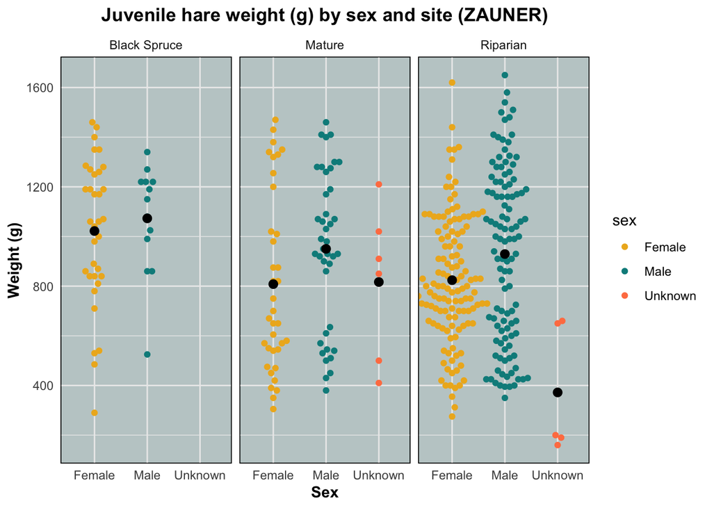

**Figure 2:** Juvenile hare weight observations (g) by sex (male, female and unknown) and site (Black Spruce, Mature and Riparian). Gold (female), teal (male) and coral (unknown) points indicate observations for weight (grams) of a juvenile hare. Black point indicates the mean value for each sex. Data: Kielland et al. (2017).

**Table 1:** Descriptive statistics (sample size, median, mean, minimum, maximum and standard deviation) for male, female and unknown juvenile hare weights (g). Data: Kielland et al. (2017)"

| Site | Sex | Sample size | Median (g) | Mean (g) | Min (g) | Max (g) | Standard deviation (g) |
| --- | --- | --- | --- | --- | --- | --- | --- |
| Black Spruce | Female | 35 | 1060 | 1022.06 | 290 | 1460 | 292.96 |
| Black Spruce | Male | 13 | 1150 | 1073.08 | 525 | 1340 | 222.64 |
| Black Spruce | Unknown | 1 | NA | NaN | Inf | -Inf | NA |
| Mature | Female | 36 | 685 | 808.19 | 305 | 1470 | 361.12 |
| Mature | Male | 40 | 965 | 950.12 | 380 | 1460 | 314.69 |
| Mature | Unknown | 7 | 880 | 816.67 | 410 | 1210 | 307.09 |
| Riparian | Female | 129 | 800 | 824.15 | 275 | 1620 | 255.04 |
| Riparian | Male | 110 | 990 | 929.27 | 350 | 1650 | 349.17 |
| Riparian | Unknown | 7 | 200 | 372.00 | 160 | 660 | 258.79 |

### Juvenile hare weights and descriptive statistics

There is a visible difference in sample sizes of juvenile hares between sites. The Riparian site has the largest sample size of weights for male (110), female (129) and unknown (7) juvenile hares, and the Black Spruce site has the fewest counts of weights for males (13), females (35) and unknown 1. The central tendency (mean) of female weights is below male weights at each site although there is a large spread (standard deviation), for Riparian females (824.15 ± 255.04; mean ± 1 standard deviation) compared to males (929.27± 349.17). The biggest take away is that the large differences in sample size (n) and large standard deviations which impact the visible trends.